# Tugas 2 MPDW

Farrel Gilbran

2023-09-10

#Panggil Package

```r
library(dplyr)
library(knitr)
library(TTR)
library(lmtest) #digunakan untuk uji formal pendeteksian autokorelasi
library(orcutt) #untuk membuat model regresi Cochrane-Orcutt
library(HoRM) #untuk membuat model regresi Hildreth-Lu
```

#Input Data

```r
library(readxl)
datap2 <- read_excel("C:/Users/farre/Downloads/data prak 2.xlsx")
Periode=datap2$Periode
O3=datap2$o3
AQI=datap2$AQI
View(datap2)
str(datap2)
```

```
## tibble [72 × 4] (S3: tbl_df/tbl/data.frame)
##  $ Periode: num [1:72] 1 2 3 4 5 6 7 8 9 10 ...
##  $ AQI    : num [1:72] 42.6 35.4 28.2 21 20 ...
##  $ o3     : num [1:72] 45.8 45.3 44.6 44.3 44 ...
##  $ date   : POSIXct[1:72], format: "2022-10-26" "2022-10-26" ...
```

#Membentuk objek time series

```r
data.ts1<-ts(datap2$AQI)
data.ts1
```

```
## Time Series:
## Start = 1
## End = 72
## Frequency = 1
##  [1] 42.6 35.4 28.2 21.0 20.0 20.0 21.0 21.0 21.0 21.0 20.0 21.0 21.0 21.0 21.0
## [16] 21.0 21.0 21.0 20.0 20.0 21.0 22.0 22.0 21.0 21.0 21.0 22.0 23.0 23.0 23.0
## [31] 23.0 23.0 23.0 22.0 21.0 19.0 19.0 22.0 24.0 23.0 22.0 21.0 20.0 20.0 20.0
## [46] 20.0 20.0 20.0 20.0 20.0 21.0 23.0 23.0 23.0 22.0 22.0 22.0 22.0 22.0 22.0
## [61] 23.0 23.0 24.0 24.0 24.0 23.0 23.0 23.0 23.0 22.0 23.0 23.0
```

```r
data.ts2<-ts(datap2$o3)
data.ts2
```

```
## Time Series:
## Start = 1
## End = 72
## Frequency = 1
##  [1] 45.77637 45.34721 44.63196 44.34586 43.98823 43.98823 44.34586 44.34586
##  [9] 44.70348 44.34586 43.98823 44.34586 44.70348 45.41874 45.77637 45.77637
## [17] 45.41874 44.70348 43.98823 43.98823 45.06111 46.49162 46.49162 45.77637
## [25] 44.34586 45.06111 47.20688 49.35265 49.35265 49.35265 49.35265 49.35265
## [33] 49.35265 48.63739 45.41874 40.76958 37.90855 38.62381 40.05432 41.12720
## [41] 41.84246 42.20009 42.91534 43.27297 43.27297 43.27297 42.91534 42.55772
## [49] 42.91534 43.63060 45.06111 45.41874 45.77637 46.49162 47.20688 47.20688
## [57] 47.20688 47.20688 47.92213 48.63739 50.06790 50.78316 51.49841 51.49841
## [65] 51.49841 50.78316 50.78316 50.06790 49.35265 48.63739 49.35265 50.06790
```

#Eksplorasi Data ##Membuat plot time series

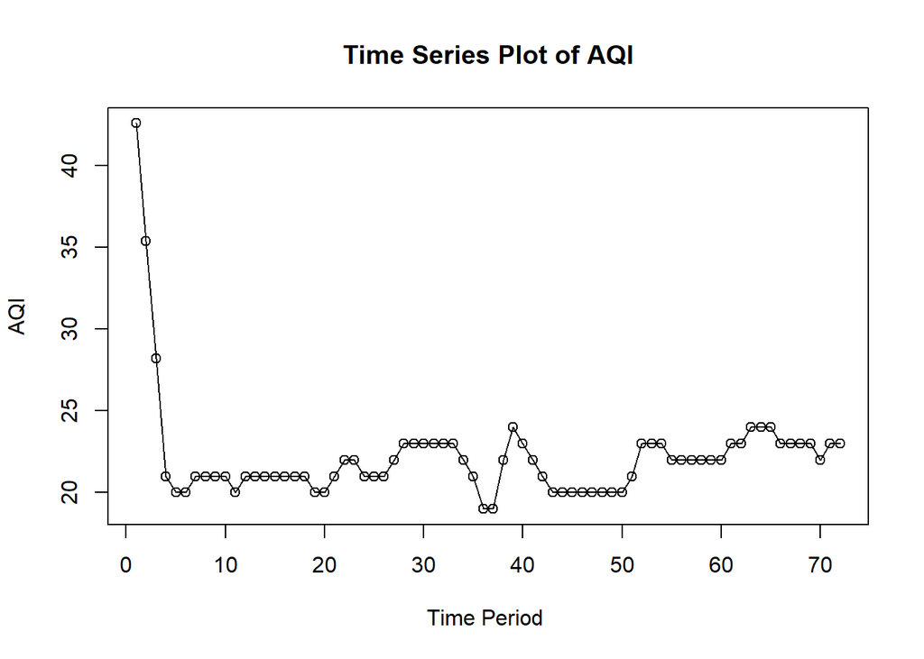

```r
ts.plot(data.ts1, xlab="Time Period ", ylab="AQI", main= "Time Series Plot of AQI")
points(data.ts1)
```

#Menampilkan Nilai Korelasi

```r
cor(Periode,AQI)
```

```
## [1] -0.1151917
```

#Membuat plot time series

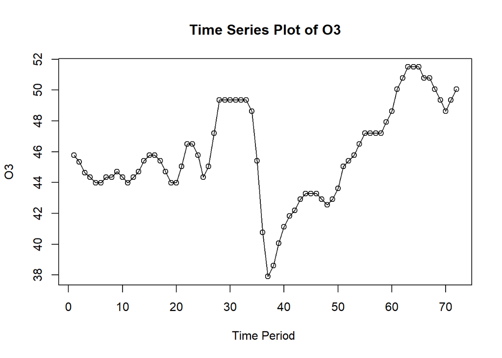

```r
ts.plot(data.ts2, xlab="Time Period ", ylab="O3", main= "Time Series Plot of O3")
points(data.ts2)
```

#Menampilkan Nilai Korelasi

```r
cor(Periode,O3)
```

```
## [1] 0.4308582
```

# Regresi

##Pembuatan Model Regresi

```r
model<- lm(AQI ~ Periode + o3 , data = datap2)
summary(model)
```

```
##
## Call:
## lm(formula = AQI ~ Periode + o3, data = datap2)
##
## Residuals:
##     Min      1Q  Median      3Q     Max
## -2.8212 -1.5445 -0.7491  0.2824 18.9216
##
## Coefficients:
##             Estimate Std. Error t value Pr(>|t|)
## (Intercept)  6.13751    5.79226   1.060  0.29302
## Periode     -0.04260    0.01958  -2.176  0.03297 *
## o3           0.38412    0.13188   2.913  0.00482 **
## ---
## Signif. codes:  0 '***' 0.001 '**' 0.01 '*' 0.05 '.' 0.1 ' ' 1
##
## Residual standard error: 3.115 on 69 degrees of freedom
## Multiple R-squared:  0.1213, Adjusted R-squared:  0.09583
## F-statistic: 4.763 on 2 and 69 DF,  p-value: 0.01155
```

#Pemeriksaan Asumsi Autokorelasi ##Uji Eksploratif

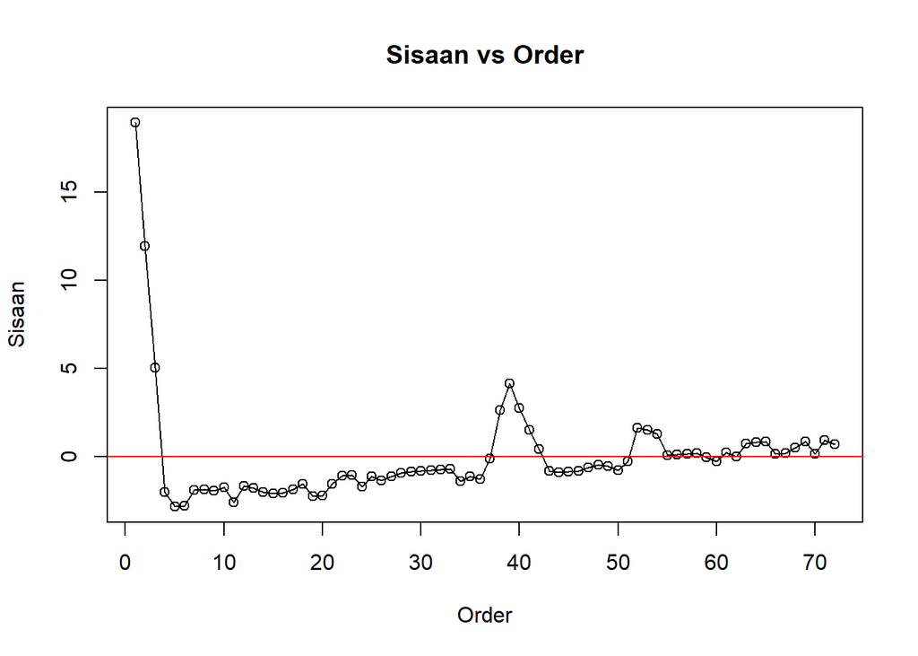

```r
residual <- residuals(model)

plot(residual, type="o",
     ylab = "Sisaan", xlab = "Order", main = "Sisaan vs Order")
abline(h = 0, col='red')
```

Terlihat plot Sisaan vs Order mengalami pola naik turun yang mengindikasikan keberadaan autokorelasi.

##Uji ACF dan PACF

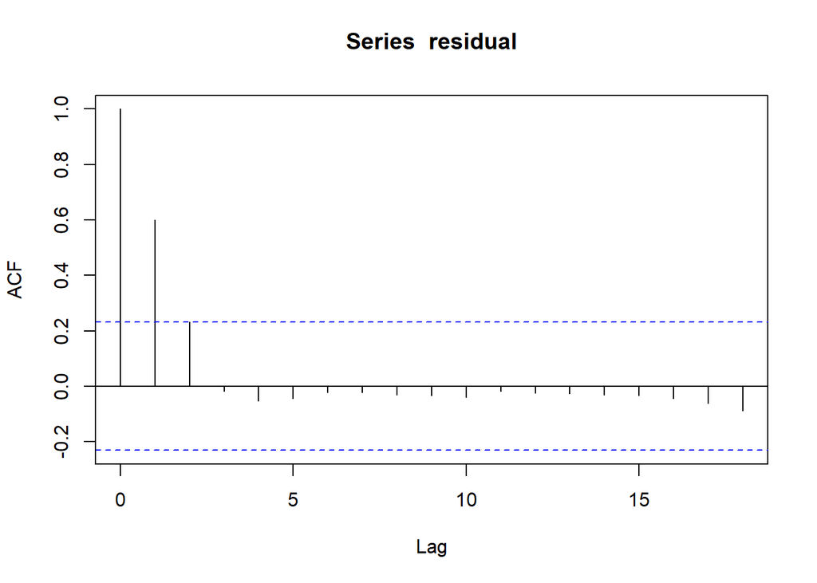

```r
acf(residual)
```

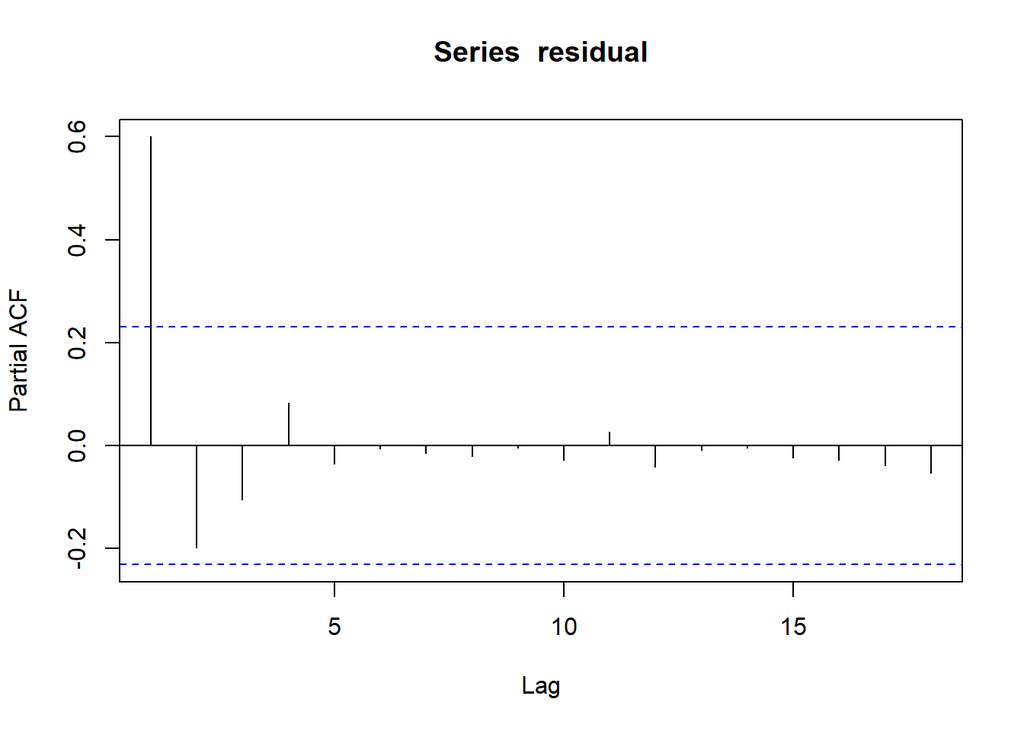

```r
pacf(residual)
```

Pada Plot ACF dan PACF, terdapat garis vertikal pada paubah Lag yang melebihi garis horizontal berwarna biru. Artinya,terindikasi terdapat autokorelasi dalam model.

##Uji Formal: Durbin Watson

H0: Tidak ada autokorelasi H1: Ada autokorelasi

```r
lmtest::dwtest(model, alternative = 'two.sided')
```

```
##
##  Durbin-Watson test
##
## data:  model
## DW = 0.26506, p-value < 2.2e-16
## alternative hypothesis: true autocorrelation is not 0
```

p-value < 0.05. Maka, Tolak H0. Hasil ini menunjukkan bahwa terdapat bukti yang sangat kuat untuk menolak hipotesis nol yang menyatakan bahwa tidak ada autokorelasi pada data. Artinya, terdapat autokorelasi yang signifikan dalam model atau data yang diuji.

#Penanganan Autokorelasi ##Metode Cochrane-Orcutt

```r
#Penanganan Autokorelasi Cochrane-Orcutt
modelCO<-cochrane.orcutt(model)
modelCO
```

```
## Cochrane-orcutt estimation for first order autocorrelation
##
## Call:
## lm(formula = AQI ~ Periode + o3, data = datap2)
##
##  number of interaction: 9
##  rho 0.596219
##
## Durbin-Watson statistic
## (original):    0.26506 , p-value: 1.854e-25
## (transformed): 1.27372 , p-value: 3.227e-04
##
##  coefficients:
## (Intercept)     Periode          o3
##    6.881838    0.021397    0.300345
```

Setelah menggunakan metode Cochrane-Orcutt untuk mengatasi autokorelasi orde pertama, terjadi peningkatan nilai Durbin-Watson dari 0.26506 menjadi 1.27372; meskipun terdapat perbaikan, nilai Durbin-Watson yang diubah masih menunjukkan kemungkinan adanya autokorelasi dalam data.

```r
#Rho optimum
rho<- modelCO$rho
rho
```

```
## [1] 0.5962188
```

```r
#Transformasi Manual
Y.trans<- datap2$AQI[-1]-datap2$AQI[-72]*rho
X1.trans<- datap2$Periode[-1]-datap2$Periode[-72]*rho
X2.trans<- datap2$o3[-1]-datap2$o3[-72]*rho


modelCOmanual<- lm(Y.trans ~ X1.trans + X2.trans)
summary(modelCOmanual)
```

```
##
## Call:
## lm(formula = Y.trans ~ X1.trans + X2.trans)
##
## Residuals:
##     Min      1Q  Median      3Q     Max
## -3.9662 -0.3595 -0.0359  0.2612  2.7399
##
## Coefficients:
##             Estimate Std. Error t value Pr(>|t|)
## (Intercept)  2.77876    1.28645   2.160 0.034299 *
## X1.trans     0.02140    0.01326   1.614 0.111143
## X2.trans     0.30034    0.07282   4.124 0.000103 ***
## ---
## Signif. codes:  0 '***' 0.001 '**' 0.01 '*' 0.05 '.' 0.1 ' ' 1
##
## Residual standard error: 0.845 on 68 degrees of freedom
## Multiple R-squared:  0.3056, Adjusted R-squared:  0.2852
## F-statistic: 14.97 on 2 and 68 DF,  p-value: 4.112e-06
```

```r
lmtest::dwtest(modelCO, alternative = 'two.sided')
```

```
##
##  Durbin-Watson test
##
## data:  modelCO
## DW = 1.2737, p-value = 0.0006453
## alternative hypothesis: true autocorrelation is not 0
```

Hasil uji Durbin-Watson (DW) adalah 1.2737, dengan nilai p sebesar 0.0006453. Hasil ini menunjukkan bahwa terdapat bukti yang cukup kuat untuk menolak hipotesis nol yang menyatakan bahwa tidak ada autokorelasi pada data. Artinya, terdapat autokorelasi yang signifikan dalam model atau data yang diuji.

##Metode Hildreth-Lu

```r
#Penanganan Autokorelasi Hildreth lu
# Hildreth-Lu
hildreth.lu.func.multi<- function(r, model){
  x <- model.matrix(model)[,-1]
  y <- model.response(model.frame(model))
  n <- length(y)
  t <- 2:n
  y <- y[t]-r*y[t-1]

  # Modifikasi untuk beberapa variabel bebas
  x1 <- x[,1][t]-r*x[,1][t-1]
  x2 <- x[,2][t]-r*x[,2][t-1]


  return(lm(y~x1+x2))
}

# Pencarian rho yang meminimumkan SSE
r <- c(seq(0.1,0.9, by= 0.1))
tab <- data.frame("rho" = r, "SSE" = sapply(r, function(i){deviance(hildreth.lu.func.multi(i, model))}))
round(tab, 4)
```

```
##   rho      SSE
## 1 0.1 214.2286
## 2 0.2 154.1771
## 3 0.3 107.5733
## 4 0.4  74.4331
## 5 0.5  54.7679
## 6 0.6  48.5636
## 7 0.7  55.7292
## 8 0.8  76.0215
## 9 0.9 109.0896
```

```r
#Rho optimal di sekitar 0.6
rOpt <- seq(0.5,0.7, by= 0.00001)
tabOpt <- data.frame("rho" = rOpt, "SSE" = sapply(rOpt, function(i){deviance(hildreth.lu.func.multi(i, model))}))
head(tabOpt[order(tabOpt$SSE),])
```

```
##          rho      SSE
## 9623 0.59622 48.55408
## 9622 0.59621 48.55408
## 9624 0.59623 48.55408
## 9621 0.59620 48.55408
## 9625 0.59624 48.55408
## 9620 0.59619 48.55408
```

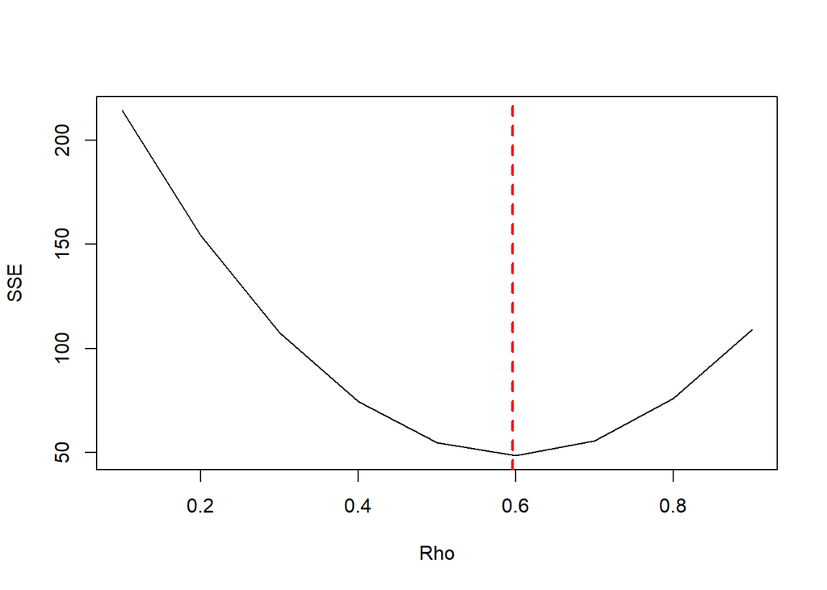

```r
#Grafik SSE optimum
par(mfrow = c(1,1))
plot(tab$SSE ~ tab$rho , type = "l", xlab = "Rho", ylab = "SSE")
abline(v = tabOpt[tabOpt$SSE==min(tabOpt$SSE),"rho"], lty = 2, col="red",lwd=2)
```

```r
#Model terbaik
modelHL <- hildreth.lu.func.multi(0, model)
summary(modelHL)
```

```
##
## Call:
## lm(formula = y ~ x1 + x2)
##
## Residuals:
##     Min      1Q  Median      3Q     Max
## -1.8063 -0.9164 -0.4285  0.0823 13.1338
##
## Coefficients:
##             Estimate Std. Error t value Pr(>|t|)
## (Intercept)  8.40906    3.83182   2.195 0.031616 *
## x1          -0.01457    0.01326  -1.099 0.275550
## x2           0.30622    0.08746   3.501 0.000822 ***
## ---
## Signif. codes:  0 '***' 0.001 '**' 0.01 '*' 0.05 '.' 0.1 ' ' 1
##
## Residual standard error: 2.057 on 68 degrees of freedom
## Multiple R-squared:  0.1552, Adjusted R-squared:  0.1304
## F-statistic: 6.249 on 2 and 68 DF,  p-value: 0.003227
```

```r
#Deteksi autokorelasi
dwtest(modelHL, , alternative = 'two.sided')
```

```
##
##  Durbin-Watson test
##
## data:  modelHL
## DW = 0.45583, p-value < 2.2e-16
## alternative hypothesis: true autocorrelation is not 0
```

Dilakukan uji autokorelasi menghasilkan hasil yang sama, tidak mengatasi masalah autokorelasi.

```r
#Perbandingan
sseModelawal <- anova(model)$`Sum Sq`[-(1:2)]
sseModelCO <- anova(modelCOmanual)$`Sum Sq`[-(1:2)]
sseModelHL <- anova(modelHL)$`Sum Sq`[-(1:2)]
mseModelawal <- sseModelawal/length(datap2$AQI)
mseModelCO <- sseModelCO/length(datap2$AQI)
mseModelHL <- sseModelHL/length(datap2$AQI)
akurasi <- matrix(c(sseModelawal,sseModelCO,sseModelHL,
                    mseModelawal,mseModelCO,mseModelHL),nrow=2,ncol=3,byrow = T)
colnames(akurasi) <- c("Model Awal", "Model Cochrane-Orcutt", "Model Hildreth-Lu")
row.names(akurasi) <- c("SSE","MSE")
akurasi
```

```
##     Model Awal Model Cochrane-Orcutt Model Hildreth-Lu
## SSE 669.698957            48.5540789        287.713390
## MSE   9.301374             0.6743622          3.996019
```

```r
kable(akurasi)
```

|  | Model Awal | Model Cochrane-Orcutt | Model Hildreth-Lu |
| --- | --- | --- | --- |
| SSE | 669.698957 | 48.5540789 | 287.713390 |
| MSE | 9.301374 | 0.6743622 | 3.996019 |

Dapat kita lihat pada hasil diatas, pada metode Cochrane-Orcutt lah yang memiliki SEE yg paling kecil dibandingkan OLS dan Hildreth-Lu